# A Study on the Relationship Between Financial Well-being and College Retention

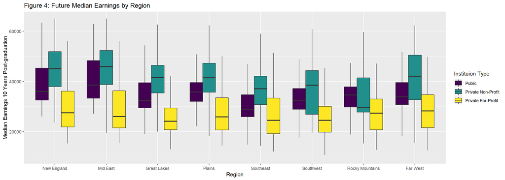

It is not surprising to observe that the median of the median earnings for the graduates of private for-profit institutions is significantly lower than that for the graduates of the other two types of institutions and aligns with the results other figures(i.e. Figure 2). We can also see that unlike public and private non-profit colleges, the income ranges for private for-profit colleges tend to be somewhat consistent throughout regions. This graph shows that financial prospects of students graduating from private for-profit colleges are similar throughout the country so we can assume that if salary beyond graduation is a major incentive for students to stay enrolled at a college, they will be inclined to either drop out or transfer colleges.

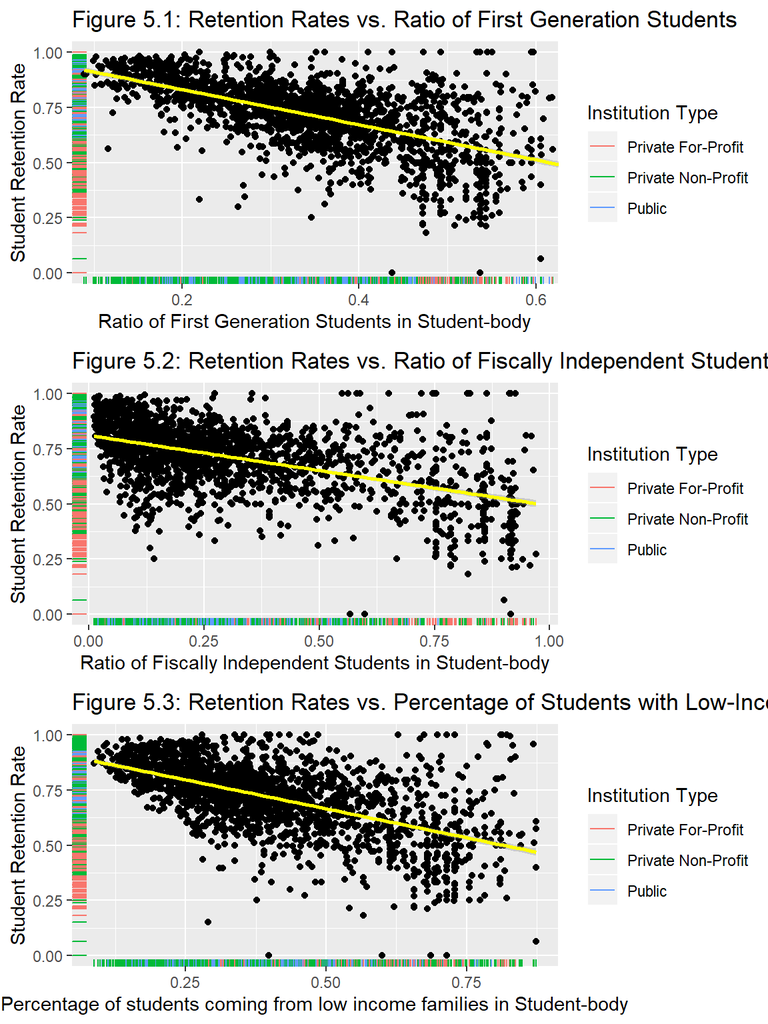

## Appendix

```
## # A tibble: 3 x 6
##   INSTITUTION_TYPE       n meanRet meanFirstGen meanFiscIndependa~ meanLowIncome
##   <ord>              <int>   <dbl>        <dbl>              <dbl>         <dbl>
## 1 Public               601   0.743        0.348              0.238         0.390
## 2 Private Non-Profit   975   0.728        0.323              0.262         0.362
## 3 Private For-Profit   233   0.538        0.478              0.720         0.630
```

As we can observe from the above table, the number of observation for private for-profit institutions are much less than those for private non-profit and public institutions. This might confirm the suspicion that private for-profit institutions are known to either hide or not provide a lot of the data and statistics regarding higher education.